# Wnioskowanie statystyczne

## Wnioskowanie statystyczne

- Wnioskowanie statystyczne to próba zidentyfikowania rozkładu i parametrów rozkładu danej zmiennej losowej. Celem jest uchwycenie wartości nieznanych parametrow.

## Wnioskowanie statystyczne

- Wnioskowanie statystyczne to próba zidentyfikowania rozkładu i parametrów rozkładu danej zmiennej losowej. Celem jest uchwycenie wartości nieznanych parametrów.
- Zajmuje się uogólnianiem wyników badań próby losowej na całą populację i stara się oszacować błędy z tym związane.
- Modele teoretyczne rozkładu zmiennej losowej (jak np. dwumianowy, normalny, Poissona) opisują rozklad zmiennej za pomoca funkcji z kilkoma parametrami.

## 4 podejścia:

1. Szacowanie wartosci nieznanego parametru w punkcie (estymacja punktowa);
2. Szacowanie przedzialu wartości parametru (estymacja przedziałowa);
3. Szacowanie prawdopodobieństwa, że parametr przyjmie okreslona wartosc (testowanie hipotez);
4. Szacowanie wartości parametru na podstawie innych zmiennych (metody regresji).

## Dwa sposoby na oszacowanie nieznanych parametrów:

1. Centralne Twierdzenie Graniczne (implikacje dużej próby);
2. Symulacja rozkładu zmiennej na podstawie modeli teoretycznych (dostępnych w R).

## ESTYMACJA PUNKTOWA

## Estymacja punktowa

1. Próba uzyskania najbardziej trafnej wartości danego parametru.
2. Oszacowany parametr nosi nazwe **estymatora.**
3. Estymatorem moze byc: **średnia, mediana, sd, var,** itp.

## Dane

- Ściagnamy bazę danych **pop1.csv** http://wozniak2.github.io/bazy
- Importujemy dane do R

```r
library(readr)
pop1 <- read_csv("pop1.csv")
```

## Dane

**pop1.csv** to baza danych zawierająca informacje na temat wzrostu obywateli pewnego miasta

## Dane

**pop1.csv** to baza danych zawierająca informacje na temat wzrostu obywateli pewnego miasta

```r
# inspekcja danych
summary(pop1)
```

```
##        id              sex                height
##  Min.   :1000082   Length:100000      Min.   :117
##  1st Qu.:3254220   Class :character   1st Qu.:162
##  Median :5502618   Mode  :character   Median :170
##  Mean   :5502428                      Mean   :170
##  3rd Qu.:7757518                      3rd Qu.:178
##  Max.   :9999937                      Max.   :217
```

```r
sd(pop1$height)
```

```
## [1] 11.23205
```

## Dane

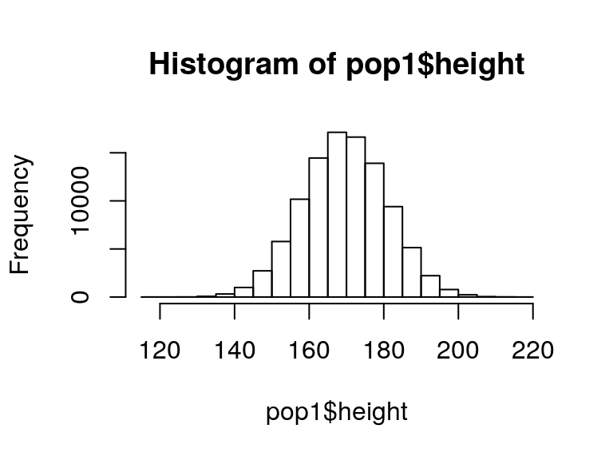

```r
# rozkład zmiennej wzrost
hist(pop1$height)
```

## Ćwiczenie 1

### Wylosujmy jedną osobę z populacji (proba jednoosobowa)

## Ćwiczenie 1

### Wylosujmy jedną osobę z populacji (proba jednoosobowa)

```r
sample(pop1$height,1)
```

```
## [1] 167
```

```r
# powtórzmy raz jeszcze
sample(pop1$height,1)
```

```
## [1] 186
```

```r
# wylosowaliśmy kogoś innego
```

## Ćwiczenie 2

### Jakie jest prawdopodobieństwo, że wylosujemy kogoś kto ma 168cm?

## Ćwiczenie 2

### Jakie jest prawdopodobieństwo, że wylosujemy kogoś kto ma 168cm?

\[ P(A)= \frac{liczba~zdarzeń~sprzyjających}{liczba~wszystkich~zdarzen} \]

## Ćwiczenie 2

### Jakie jest prawdopodobieństwo, ze wylosujemy kogoś kto ma 168cm?

## Ćwiczenie 2

### Jakie jest prawdopodobieństwo, ze wylosujemy kogoś kto ma 168cm?

```r
#Jest to stosunek liczby osób mających 168 cm do całkowitej populacji
sum(pop1$height==168)/length(pop1$height)
```

```
## [1] 0.03476
```

## Ćwiczenie 3

### Losujemy próbę 100 osobową z populacji i porównujemy średni wzrost z próby ze średnim wzrostem całej populacji

```r
X.samp <- sample(pop1$height,100)
# średnia z wylosowanej próby
mean(X.samp)
```

```
## [1] 170.74
```

```r
# średnia z populacji
mean(pop1$height)
```

```
## [1] 170.035
```

## Ćwiczenie 3

### Losujemy próbę 100 osobową z populacji i porównujemy średni wzrost z próby ze średnim wzrostem całej populacji

- Czy mieliśmy szczęście w losowaniu?
- Jak bardzo średnia z próby odpowiadała wartości średniej dla całej populacji?

## Powtórzmy losowanie próby 100 osobowej

```r
X.samp <- sample(pop1$height,100)
# średnia z wylosowanej próby
mean(X.samp)
```

```
## [1] 172.05
```

```r
# średnia z populacji
mean(pop1$height)
```

```
## [1] 170.035
```

## Ćwiczenie 4

### Jakie jest prawdopodobieństwo, ze wylosowana próba odwzoruje średni wzrost populacji z dokładnością do 1 cm?

## Ćwiczenie 4

### Jakie jest prawdopodobieństwo, ze wylosowana próba odwzoruje średni wzrost populacji z dokładnością do 1 cm?

To prawdopodobieństwo jest stosunkiem prób, gdzie średnia z próby nie przekracza 1cm w stosunku do populacji do **wszystkich** prób (dużej liczby prób).

## Ćwiczenie 4

Możemy więc obliczyć **przybliżone prawdopodobieństwo**. Niech próba będzie 100 osobowa, a prób będzie 100000.

## Ćwiczenie 4

Możemy więc obliczyć **przybliżone prawdopodobieństwo**. Niech próba będzie 100 osobowa, a prób będzie 100000.

```r
X.bar <- NULL
for(i in 1:10^5)
{
X.samp <- sample(pop1$height,100)
X.bar[i] <- mean(X.samp)
}
```

## Ćwiczenie 4 - analiza wyników

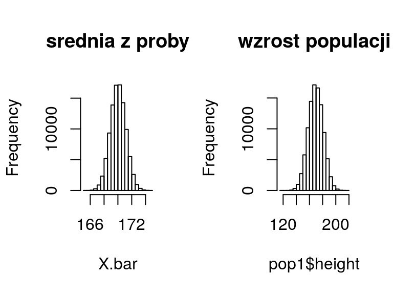

```r
#Porownajmy rozkład wzrostu w populacji ze średnia z prób
par(mfrow=c(1,2))
hist(X.bar, main="srednia z proby")
hist(pop1$height, main="wzrost populacji")
```

## Ćwiczenie 4 - wnioski

- Średni wzrost z próby jest bardzo zbliżony do średniego wzrostu populacji
- Rozkład zmiennej w próbie jest bardziej skondensowany wokół najczęściej pojawiających sie wartości.

## Ćwiczenie 5

- Jakie jest prawdopodobienstwo tego, ze wylosowana próba odda średni wzrost populacji z dokładnością do 1 cm?

## Ćwiczenie 5

- Jakie jest prawdopodobienstwo tego, ze wylosowana próba odda średni wzrost populacji z dokładnością do 1 cm?

```r
# odejmujemy średnią w populacji od każdej średniej
# z wylosowanych prób i sprawdzamy czy nie przekracza
# 1 cm
mean(abs(X.bar - mean(pop1$height)) <= 1)
```

```
## [1] 0.62434
```

## Ćwiczenie 6

Zidentyfikuj centralny obszar zawierający 80% wszystkich obserwacji dla średniej wartości zmiennej wzrost w wylosowanej próbie i porównaj go z teoretycznym rozkładem normalnym. Wnioski?

```r
## wartości graniczne w próbie
quantile(X.bar, c(0.1, 0.9))
```

```
##    10%    90%
## 168.59 171.48
```

```r
## przybliżenie rozkładem normalnym
qnorm(c(0.1, 0.9), mean(X.bar), sd(X.bar))
```

```
## [1] 168.5894 171.4768
```

## Zadanie domowe

Dane (pop2.csv): wozniak2.github.io/bazy

1. Oblicz oczekiwana średnią wartość zmiennej “bmi” dla losowej proby N=150 (pamiętaj, aby powtórzyć losowanie wielokrotnie, tak aby rezulaty były jak najbardziej rzetelne).Porównaj średnią z próby ze średnią w populacji
2. Jakie jest prawdopodobieństwo, że średnia z próby odda nam średnią z populacji z dokładnością do 0.5 BMI
3. Zidentyfikuj centralny obszar zawierajacy 80% wszystkich srednich wartosci “bmi”.
4. Przybliż obszar z poprzedniego punktu za pomocą rozkładu normalnego. Czy w tym przypadku rozkład normalny jest dobrym przybliżeniem dla zmiennej?

## Zadanie domowe - opis zmiennych

**id**: identyfikator pacjenta  
**sex**: płeć  
**age**: wiek  
**bmi**: body mass index  
**systolic**: skurczowe ciśnienie krwi  
**diastolic**: rozkurczowe ciśnienie krwi

## Dane

- Ściagnamy bazę danych **pop2.csv**
- Importujemy dane do R

```r
library(readr)
pop2 <- read_csv("pop2.csv")
```

## Zadanie domowe

```r
X.bar <- NULL
for(i in 1:10^5)
{
X.samp <- sample(pop2$bmi, 150)
X.bar[i] <- mean(X.samp)
}
```

## Zadanie domowe

Jakie jest prawdopodobieństwo, że średnia z próby odda nam średnią z populacji z dokładnością do 0.5 BMI

```r
# odejmujemy średnią w populacji od każdej średniej
# z wylosowanych prób i sprawdzamy czy nie przekracza
# 0.5 bmi
mean(abs(X.bar - mean(pop2$bmi)) <= 0.5)
```

```
## [1] 0.85715
```

## Zadanie domowe

Zidentyfikuj centralny obszar zawierajacy 80% wszystkich srednich wartosci “bmi”.

```r
quantile(X.bar, c(0.1, 0.9))
```

```
##      10%      90%
## 24.54948 25.42189
```

Przybliż obszar z poprzedniego punktu za pomocą rozkładu normalnego. Czy w tym przypadku rozkład normalny jest dobrym przybliżeniem dla zmiennej?

```r
qnorm(c(0.1, 0.9), mean(X.bar), sd(X.bar))
```

```
## [1] 24.54802 25.42229
```